# TP5 — Cultures, Intrants et Rendements Agricoles

Nigeria GHS Panel Wave 4 (2018-2019) | Post-Harvest

NGUEAJIO David et Serigne Ndame LO

19 avril 2026

# 1 Introduction

Ce rapport analyse les **cultures pratiquées, les intrants agricoles utilisés et les rendements obtenus** par les exploitations agricoles nigérianes à partir du *Nigeria General Household Survey (GHS) Panel — Wave 4 (2018-2019)*, collecté dans le cadre du programme LSMS-ISA de la Banque Mondiale.

# 2 Chargement des packages et des données

```r
library(haven)      # lecture fichiers .dta
library(dplyr)      # manipulation données
library(tidyr)      # pivots
library(forcats)    # facteurs ordonnés
library(ggplot2)    # visualisations
library(scales)     # formatage axes
library(patchwork)  # assemblage graphiques
library(rstatix)    # tests statistiques
library(ggpubr)     # annotations statistiques
library(gtsummary)  # tableaux résumés
```

```r
# --- Chemins (adapter si besoin) ---
path_raw <- "../data/raw/"

# Fichier 1 : cultures par parcelle (Wave 4)
# Note BM : correspond à sect11f_plantingw4 dans le catalogue officiel,
# mais le fichier distribué porte le nom secta3ii_harvestw4
df_crops <- read_dta(paste0(path_raw, "secta3ii_harvestw4.dta"))

# Fichier 2 : intrants / engrais (Section 11C2 du questionnaire W4)
df_fert  <- read_dta(paste0(path_raw, "secta11c2_harvestw4.dta"))

# Fichier 3 : production récoltée (harvest questionnaire Wave 4)
df_prod  <- read_dta(paste0(path_raw, "secta9a_harvestw4.dta"))

# Fichier 4 : roster des parcelles (superficie GPS et déclarée)
df_plots <- read_dta(paste0(path_raw, "secta1_harvestw4.dta"))

# Encodage officiel du secteur (questionnaire W4, Section A1, Q4) :
# Urban = 1 | Rural = 2
sector_labels <- c("1" = "Urbain", "2" = "Rural")
```

```r
cat("=== df_crops ===\n"); glimpse(df_crops)
```

```
## === df_crops ===
```

```
## Rows: 8,839
## Columns: 62
## $ zone         <dbl+lbl> 4, 4, 4, 4, 4, 4, 4, 4, 4, 4, 4, 4, 4, 4, 4, 4, 4, 4,…
## $ state        <dbl+lbl> 1, 1, 1, 1, 1, 1, 1, 1, 1, 1, 1, 1, 1, 1, 1, 1, 1, 1,…
## $ lga          <dbl+lbl> 105, 111, 111, 107, 107, 107, 107, 107, 107, 107, 107…
## $ sector       <dbl+lbl> 2, 1, 1, 2, 2, 2, 2, 2, 2, 2, 2, 2, 2, 2, 2, 2, 2, 1,…
## $ ea           <dbl> 0, 1146, 1146, 1044, 1044, 1044, 1044, 1044, 1044, 1044, …
## $ hhid         <dbl> 10009, 10031, 10031, 10061, 10061, 10061, 10061, 10061, 1…
## $ cropcode     <dbl+lbl> 1080, 1080, 2190, 1020, 1080, 1121, 1124, 2060, 2080,…
## $ sa3iiq1a     <dbl> 10.0, 1.0, 4.0, 15.0, 10.0, 9.0, 5.0, 10.0, 7.0, 7.0, 150…
## $ sa3iiq1c     <dbl+lbl> 130, 130, 160, 130, 130, 150, 130, 130, 130, 130, 100…
## $ sa3iiq1d     <dbl+lbl> 10, 10,  0, 11, 10,  1, 11, 10, 10, 10,  1, 11, 10, 1…
## $ sa3iiq1b     <dbl+lbl>  1,  1, NA, NA,  1, NA, NA, NA, NA, NA, NA, NA,  1, N…
## $ sa3iiq1_conv <dbl> 9.000, 9.000, 0.480, 50.000, 9.000, 34.980, 50.000, 25.00…
## $ sa3iiq3      <dbl+lbl> 1, 2, 2, 1, 1, 1, 1, 1, 1, 1, 1, 1, 1, 1, 1, 1, 1, 1,…
```

[output cut: 49 more lines]

```r
cat("=== df_fert ===\n");  glimpse(df_fert)
```

```
## === df_fert ===
```

```
## Rows: 8,293
## Columns: 41
## $ zone           <dbl+lbl> 4, 4, 4, 4, 4, 4, 4, 4, 4, 4, 4, 4, 4, 4, 4, 4, 4, …
## $ state          <dbl+lbl> 1, 1, 1, 1, 1, 1, 1, 1, 1, 1, 1, 1, 1, 1, 1, 1, 1, …
## $ lga            <dbl+lbl> 105, 105, 111, 107, 107, 107, 107, 107, 107, 107, 1…
## $ sector         <dbl+lbl> 2, 2, 1, 2, 2, 2, 2, 2, 2, 2, 2, 2, 2, 2, 2, 2, 2, …
## $ ea             <dbl> 0, 0, 1146, 1044, 1044, 1044, 1044, 1044, 1044, 1044, 1…
## $ hhid           <dbl> 10009, 10009, 10031, 10061, 10061, 10061, 10061, 10061,…
## $ plotid         <dbl> 1, 2, 1, 1, 2, 3, 4, 5, 6, 1, 2, 3, 1, 2, 3, 1, 2, 3, 1…
## $ s11c2q10       <dbl+lbl> 1, 1, 2, 2, 2, 2, 2, 2, 2, 2, 2, 2, 2, 2, 2, 2, 2, …
## $ s11c2q11a      <dbl> 8, 5, NA, NA, NA, NA, NA, NA, NA, NA, NA, NA, NA, NA, N…
## $ s11c2q11b      <dbl+lbl>  3,  3, NA, NA, NA, NA, NA, NA, NA, NA, NA, NA, NA,…
## $ s11c2q11_conv  <dbl> 1, 1, NA, NA, NA, NA, NA, NA, NA, NA, NA, NA, NA, NA, N…
## $ s11c2q1        <dbl+lbl> 1, 1, 2, 1, 1, 2, 2, 2, 1, 2, 2, 2, 1, 2, 2, 2, 2, …
## $ s11c2q2a       <dbl> 5.0, 4.0, NA, 2.0, 1.8, NA, NA, NA, 1.5, NA, NA, NA, 0.…
```

[output cut: 28 more lines]

```r
cat("=== df_prod ===\n");  glimpse(df_prod)
```

```
## === df_prod ===
```

```
## Rows: 308
## Columns: 18
## $ zone    <dbl+lbl> 4, 4, 4, 4, 4, 4, 4, 4, 4, 4, 2, 2, 2, 2, 2, 2, 5, 5, 5, 5…
## $ state   <dbl+lbl> 1, 1, 1, 1, 1, 1, 1, 1, 1, 1, 2, 2, 2, 2, 2, 2, 3, 3, 3, 3…
## $ lga     <dbl+lbl> 107, 107, 113, 113, 113, 113, 113, 113, 113, 113, 207, 207…
## $ sector  <dbl+lbl> 2, 2, 2, 2, 2, 2, 2, 2, 2, 2, 2, 2, 2, 2, 2, 2, 2, 2, 2, 2…
## $ ea      <dbl> 10, 10, 6, 6, 6, 6, 6, 6, 284, 284, 1302, 1302, 668, 668, 668,…
## $ hhid    <dbl> 19066, 19066, 19169, 19169, 19174, 19174, 19177, 19177, 19201,…
## $ fishid  <dbl+lbl> 1, 2, 1, 2, 1, 2, 1, 2, 1, 2, 1, 2, 1, 2, 1, 2, 1, 2, 1, 2…
## $ sa9aq1  <dbl+lbl> 1, 2, 1, 2, 2, 1, 1, 1, 2, 1, 1, 2, 1, 2, 2, 1, 1, 2, 1, 2…
## $ sa9aq2  <dbl> 12, NA, 52, NA, NA, NA, 48, NA, NA, NA, 3, NA, 1, NA, NA, NA, …
## $ sa9aq3a <dbl> 48, NA, 1, NA, NA, 50, 1, 7, NA, 525, 19, NA, 2, NA, NA, 2, 50…
## $ sa9aq3b <dbl+lbl>  81,  NA, 150,  NA,  NA,  81, 140, 140,  NA,  81, 150,  NA…
## $ sa9aq4  <dbl+lbl>  2, NA,  2, NA, NA,  1,  1,  1, NA,  2,  2, NA,  2, NA, NA…
## $ sa9aq5  <dbl> NA, NA, NA, NA, NA, NA, 40, NA, NA, NA, NA, NA, NA, NA, NA, NA…
## $ sa9aq6a <dbl> NA, NA, NA, NA, NA, 30, 1, 6, NA, NA, NA, NA, NA, NA, NA, NA, …
## $ sa9aq6b <dbl+lbl>  NA,  NA,  NA,  NA,  NA,  81, 140, 140,  NA,  NA,  NA,  NA…
## $ sa9aq7  <dbl> NA, NA, NA, NA, NA, NA, 8000, NA, NA, NA, NA, NA, NA, NA, NA, …
## $ sa9aq8a <dbl+lbl>   48,   NA,   15,   NA,   NA,   20,    3,    1,   NA,    0…
## $ sa9aq8b <dbl+lbl>  81,  NA,  80,  NA,  NA,  81,  80, 140,  NA,  NA,  81,  NA…
```

```r
cat("=== df_plots ===\n"); glimpse(df_plots)
```

```
## === df_plots ===
```

```
## Rows: 10,961
## Columns: 35
## $ zone               <dbl+lbl> 4, 4, 4, 4, 4, 4, 4, 4, 4, 4, 4, 4, 4, 4, 4, 4,…
## $ state              <dbl+lbl> 1, 1, 1, 1, 1, 1, 1, 1, 1, 1, 1, 1, 1, 1, 1, 1,…
## $ lga                <dbl+lbl> 115, 115, 115, 115, 105, 105, 115, 111, 111, 11…
## $ sector             <dbl+lbl> 1, 1, 1, 1, 2, 2, 1, 1, 1, 1, 1, 1, 1, 2, 2, 2,…
## $ ea                 <dbl> 670, 670, 670, 670, 0, 0, 670, 1146, 1146, 1146, 11…
## $ hhid               <dbl> 10002, 10003, 10004, 10008, 10009, 10009, 10010, 10…
## $ plotid             <dbl> 1, 1, 1, 1, 1, 2, 1, 1, 1, 1, 1, 1, 1, 1, 2, 3, 4, …
## $ sa1q1aa            <dbl+lbl> 2, 2, 2, 2, 1, 1, 2, 1, 2, 2, 2, 2, 2, 1, 1, 1,…
## $ sa1q1a             <dbl+lbl> 2, 2, 2, 2, 1, 1, 2, 1, 2, 2, 2, 2, 2, 1, 1, 1,…
## $ prefilled_gps_area <dbl> NA, NA, NA, NA, 18811.00, 1953.90, NA, 505.89, NA, …
## $ sa1q1d             <dbl+lbl> 2, 2, 2, 2, 2, 2, 2, 2, 2, 2, 2, 2, 2, 2, 2, 2,…
## $ sa1q3              <dbl> 1, 2, 2, 2, 2, 2, 1, 1, 2, 8, 1, 1, 1, 1, 1, 1, 1, …
## $ sa1q4              <dbl+lbl> 1, 1, 1, 1, 1, 1, 1, 1, 1, 1, 1, 1, 1, 1, 1, 1,…
```

[output cut: 22 more lines]

# 3 Tâche 25 — Les 15 cultures les plus fréquentes (W4)

## 3.1 Construction du classement

```r
# Table de correspondance codes → noms et types de cultures
# Source : LSMS Crop Classification & questionnaire W4
crop_labels <- tibble(
  cropcode = c(1080, 1050, 1070, 1110, 1100, 1040, 1030,
               2010, 2040, 2030, 2020, 2050,
               1020, 1120, 1060, 1140,
               5010, 5050, 3020, 3010),
  crop_name = c("Maïs", "Mil", "Sorgho", "Riz", "Blé", "Patate douce",
                "Taro/Cocoyam", "Niébé", "Arachide", "Soja", "Haricot",
                "Pois bambara", "Manioc", "Igname", "Macabo", "Plantain",
                "Coton", "Canne à sucre", "Tomate", "Légumes feuilles"),
  crop_type = c("Céréale","Céréale","Céréale","Céréale","Céréale",
                "Tubercule","Tubercule",
                "Légumineuse","Légumineuse","Légumineuse","Légumineuse","Légumineuse",
                "Tubercule","Tubercule","Tubercule","Tubercule",
                "Culture de rente","Culture de rente",
                "Maraîchère","Maraîchère")
)

# Fréquence des cultures (nb de parcelles plantées avec chaque culture)
top15 <- df_crops %>%
  filter(!is.na(cropcode)) %>%
  count(cropcode, name = "freq") %>%
  arrange(desc(freq)) %>%
  slice_head(n = 15) %>%
  left_join(crop_labels, by = "cropcode") %>%
  mutate(
    crop_name = if_else(is.na(crop_name),
                        paste("Code", cropcode), crop_name),
    crop_type = if_else(is.na(crop_type), "Autre", crop_type),
    prop      = freq / sum(freq),
    crop_name = fct_reorder(crop_name, freq)
  )

top15
```

| cropcode | freq | crop_name | crop_type | prop |
| --- | --- | --- | --- | --- |
| 1080 | 1797 | Maïs | Céréale | 0.23349792 |
| 1070 | 1001 | Sorgho | Céréale | 0.13006757 |
| 1121 | 708 | Code 1121 | Autre | 0.09199584 |
| 1010 | 653 | Code 1010 | Autre | 0.08484927 |
| 1100 | 619 | Blé | Céréale | 0.08043139 |
| 1020 | 604 | Manioc | Tubercule | 0.07848233 |
| 1060 | 594 | Macabo | Tubercule | 0.07718295 |
| 1110 | 500 | Riz | Céréale | 0.06496881 |
| 2220 | 215 | Code 2220 | Autre | 0.02793659 |
| 2120 | 207 | Code 2120 | Autre | 0.02689709 |

[output cut: 5 more lines]

## 3.2 Visualisation

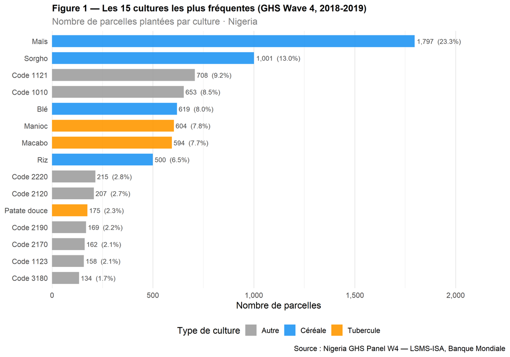

```r
type_colors <- c(
  "Céréale"         = "#2196F3",
  "Légumineuse"     = "#4CAF50",
  "Tubercule"       = "#FF9800",
  "Culture de rente"= "#9C27B0",
  "Maraîchère"      = "#F44336",
  "Autre"           = "#9E9E9E"
)

ggplot(top15, aes(x = crop_name, y = freq, fill = crop_type)) +
  geom_col(width = 0.7, alpha = 0.9) +
  geom_text(
    aes(label = paste0(comma(freq), "  (", percent(prop, accuracy = 0.1), ")")),
    hjust = -0.05, size = 3.3, color = "grey30"
  ) +
  coord_flip() +
  scale_fill_manual(values = type_colors, name = "Type de culture") +
  scale_y_continuous(
    expand = expansion(mult = c(0, 0.25)),
    labels = comma
  ) +
  labs(
    title    = "Figure 1 — Les 15 cultures les plus fréquentes (GHS Wave 4, 2018-2019)",
    subtitle = "Nombre de parcelles plantées par culture · Nigeria",
    x        = NULL,
    y        = "Nombre de parcelles",
    caption  = "Source : Nigeria GHS Panel W4 — LSMS-ISA, Banque Mondiale"
  ) +
  theme_minimal(base_size = 13) +
  theme(
    plot.title      = element_text(face = "bold", size = 13),
    plot.subtitle   = element_text(color = "grey50"),
    legend.position = "bottom",
    panel.grid.major.y = element_blank()
  )
```

**Commentaire.** Les céréales dominent le système agricole nigérian en vague 4.

# 4 Tâche 26 — Indice de diversification culturale par ménage

## 4.1 Calcul de l’indice

```r
# Nombre de cultures distinctes par ménage
hh_crop <- df_crops %>%
  filter(!is.na(cropcode)) %>%
  group_by(hhid) %>%
  summarise(
    nb_crops = n_distinct(cropcode),
    sector   = first(sector),
    .groups  = "drop"
  ) %>%
  mutate(
    milieu = factor(sector, levels = c(1, 2), labels = c("Urbain", "Rural"))
  )

# Statistiques descriptives
hh_crop %>%
  group_by(milieu) %>%
  summarise(
    n       = n(),
    Moyenne = round(mean(nb_crops), 2),
    Médiane = median(nb_crops),
    Écart_type = round(sd(nb_crops), 2),
    Q1 = quantile(nb_crops, 0.25),
    Q3 = quantile(nb_crops, 0.75)
  )
```

| milieu | n | Moyenne | Médiane | Écart_type | Q1 | Q3 |
| --- | --- | --- | --- | --- | --- | --- |
| Urbain | 496 | 2.41 | 2 | 1.37 | 1 | 3 |
| Rural | 2757 | 2.77 | 3 | 1.48 | 2 | 4 |

## 4.2 Distribution globale (histogramme)

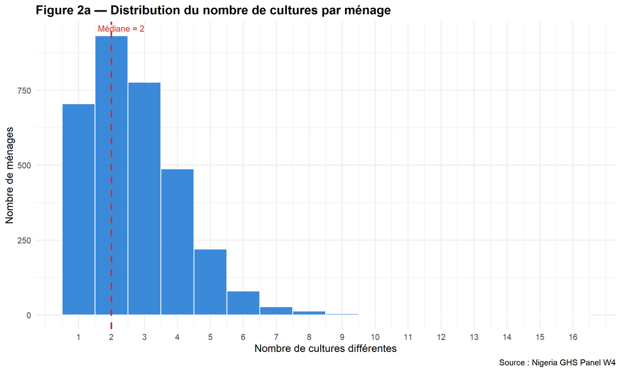

```r
p_hist <- ggplot(hh_crop, aes(x = nb_crops)) +
  geom_histogram(
    binwidth = 1, fill = "#1976D2", color = "white", alpha = 0.85
  ) +
  geom_vline(
    xintercept = median(hh_crop$nb_crops),
    linetype = "dashed", color = "#D32F2F", linewidth = 1
  ) +
  annotate(
    "text",
    x     = median(hh_crop$nb_crops) + 0.3,
    y     = Inf, vjust = 1.5,
    label = paste("Médiane =", median(hh_crop$nb_crops)),
    color = "#D32F2F", size = 3.5
  ) +
  scale_x_continuous(breaks = 1:max(hh_crop$nb_crops)) +
  labs(
    title    = "Figure 2a — Distribution du nombre de cultures par ménage",
    x        = "Nombre de cultures différentes",
    y        = "Nombre de ménages",
    caption  = "Source : Nigeria GHS Panel W4"
  ) +
  theme_minimal(base_size = 12) +
  theme(plot.title = element_text(face = "bold"))

p_hist
```

## 4.3 Comparaison Rural / Urbain

```r
# Test de Wilcoxon-Mann-Whitney
wilcox_res <- wilcox.test(nb_crops ~ milieu, data = hh_crop, conf.int = TRUE)

# Taille d'effet (r de rang)

wilcox_r <- rstatix::wilcox_effsize(hh_crop, nb_crops ~ milieu)

cat("=== Test de Wilcoxon ===\n")
```

```
## === Test de Wilcoxon ===
```

```r
print(wilcox_res)
```

[output not shown]

```r
cat("\nTaille d'effet (r de rang) :", round(wilcox_r$effsize, 3), "\n")
```

```
##
## Taille d'effet (r de rang) : 0.102
```

```r
cat("Interprétation :", as.character(wilcox_r$magnitude), "\n")
```

```
## Interprétation : small
```

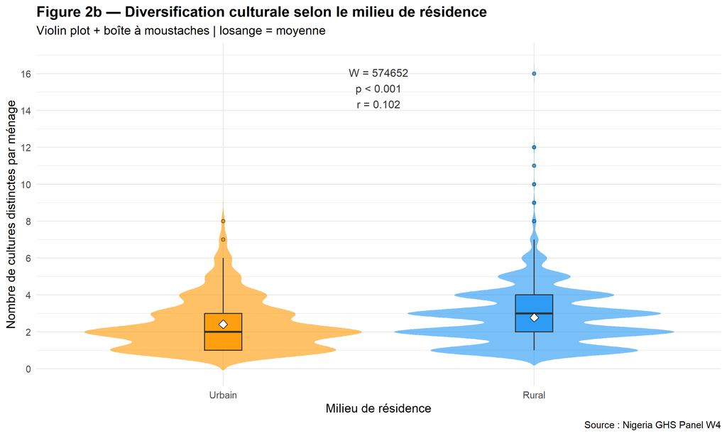

```r
p_violin <- ggplot(hh_crop, aes(x = milieu, y = nb_crops, fill = milieu)) +
  geom_violin(trim = FALSE, alpha = 0.6, color = NA) +
  geom_boxplot(width = 0.12, outlier.shape = 21, outlier.size = 1.5,
               alpha = 0.85) +
  stat_summary(fun = mean, geom = "point", shape = 23, size = 3,
               fill = "white", color = "black") +
  scale_fill_manual(values = c("Urbain" = "#FF9800", "Rural" = "#2196F3")) +
  scale_y_continuous(breaks = seq(0, max(hh_crop$nb_crops), 2)) +
  annotate(
    "text", x = 1.5, y = max(hh_crop$nb_crops) * 0.95,
    label = paste0("W = ", round(wilcox_res$statistic),
                   "\np ", ifelse(wilcox_res$p.value < 0.001, "< 0.001",
                                  paste("=", round(wilcox_res$p.value, 3))),
                   "\nr = ", round(wilcox_r$effsize, 3)),
    size = 3.8, color = "grey20"
  ) +
  labs(
    title    = "Figure 2b — Diversification culturale selon le milieu de résidence",
    subtitle = "Violin plot + boîte à moustaches | losange = moyenne",
    x        = "Milieu de résidence",
    y        = "Nombre de cultures distinctes par ménage",
    fill     = NULL,
    caption  = "Source : Nigeria GHS Panel W4"
  ) +
  theme_minimal(base_size = 12) +
  theme(
    plot.title      = element_text(face = "bold"),
    legend.position = "none"
  )

p_violin
```

**Commentaire.** Le test de Wilcoxon-Mann-Whitney permet de comparer les distributions sans hypothèse de normalité. La taille d’effet *r* de rang quantifie l’amplitude de la différence entre milieux. Les ménages ruraux pratiquent généralement une agriculture plus diversifiée que les ménages urbains, ce qui reflète la logique de subsistance et de résilience face aux aléas climatiques.

# 5 Tâche 27 — Utilisation des engrais par type, zone et État

## 5.1 Préparation des données

```r
# Correction de l'hhid aberrant identifié dans l'exploration
# (ménage 99002 avec valeurs manquantes systématiques sur tous les intrants)
df_fert_clean <- df_fert %>%
  filter(hhid != 99002) %>%
  mutate(
    # Indicateurs binaires (1 = utilisé, 0 = non utilisé)
    # Variables confirmées depuis le questionnaire Section 11C2 :
    # s11dq1a    = utilisation engrais inorganique (oui/non)
    # s11dq36    = utilisation engrais organique
    # s11c2q36_1 = type NPK
    # s11c2q36_2 = type urée
    # s11c2q36_99= autre type
    use_inorganic = if_else(s11dq1a  == 1, 1L, 0L, missing = 0L),
    use_organic   = if_else(s11dq36  == 1, 1L, 0L, missing = 0L),
    use_npk       = if_else(s11c2q36_1  == 1, 1L, 0L, missing = 0L),
    use_urea      = if_else(s11c2q36_2  == 1, 1L, 0L, missing = 0L),
    use_other     = if_else(s11c2q36_99 == 1, 1L, 0L, missing = 0L)
  )

# Agrégation au niveau ménage (max = ménage ayant utilisé sur au moins 1 parcelle)
fert_hh <- df_fert_clean %>%
  group_by(hhid) %>%
  summarise(
    inorganic = max(use_inorganic, na.rm = TRUE),
    organic   = max(use_organic,   na.rm = TRUE),
    npk       = max(use_npk,       na.rm = TRUE),
    urea      = max(use_urea,      na.rm = TRUE),
    other     = max(use_other,     na.rm = TRUE),
    sector    = first(sector),
    state     = first(state),
    zone      = first(zone),
    .groups   = "drop"
  ) %>%
  mutate(
    milieu = factor(sector, levels = c(1, 2), labels = c("Urbain", "Rural"))
  )
```

```r
tab_chi <- table(Milieu = fert_hh$milieu, Engrais_inorganique = fert_hh$inorganic)
cat("=== Tableau de contingence ===\n")
```

```
## === Tableau de contingence ===
```

```r
print(addmargins(tab_chi))
```

```
##         Engrais_inorganique
## Milieu      0    1  Sum
##   Urbain  378  167  545
##   Rural  1641 1270 2911
##   Sum    2019 1437 3456
```

```r
chi_res  <- chisq.test(tab_chi)
cramer_v <- rstatix::cramer_v(tab_chi)

cat("\n=== Test du chi-deux ===\n")
```

```
##
## === Test du chi-deux ===
```

```r
print(chi_res)
```

```
##
##  Pearson's Chi-squared test with Yates' continuity correction
##
## data:  tab_chi
## X-squared = 31.334, df = 1, p-value = 2.172e-08
```

```r
cat("\nV de Cramér =", round(cramer_v, 4), "\n")
```

```
##
## V de Cramér = 0.0952
```

## 5.3 Barplot groupé avec IC 95%

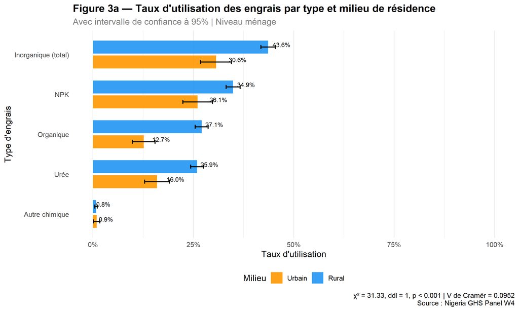

```r
# Taux par milieu pour chaque type d'engrais
fert_long <- fert_hh %>%
  pivot_longer(
    cols      = c(inorganic, organic, npk, urea, other),
    names_to  = "type_engrais",
    values_to = "utilise"
  ) %>%
  group_by(milieu, type_engrais) %>%
  summarise(
    n     = n(),
    rate  = mean(utilise, na.rm = TRUE),
    se    = sqrt(rate * (1 - rate) / n),
    lower = pmax(rate - 1.96 * se, 0),
    upper = pmin(rate + 1.96 * se, 1),
    .groups = "drop"
  ) %>%
  mutate(
    type_engrais = recode(type_engrais,
      inorganic = "Inorganique (total)",
      organic   = "Organique",
      npk       = "NPK",
      urea      = "Urée",
      other     = "Autre chimique"
    ),
    type_engrais = fct_reorder(type_engrais, rate, .fun = max)
  )

ggplot(fert_long, aes(x = type_engrais, y = rate, fill = milieu)) +
  geom_col(position = position_dodge(width = 0.75), width = 0.65, alpha = 0.9) +
  geom_errorbar(
    aes(ymin = lower, ymax = upper),
    position = position_dodge(width = 0.75),
    width = 0.2, linewidth = 0.7
  ) +
  geom_text(
    aes(label = percent(rate, accuracy = 0.1), y = upper + 0.015),
    position = position_dodge(width = 0.75),
    size = 3, vjust = 0
  ) +
  coord_flip() +
  scale_y_continuous(
    labels = percent_format(accuracy = 1),
    limits = c(0, 1)
  ) +
  scale_fill_manual(
    values = c("Urbain" = "#FF9800", "Rural" = "#2196F3"),
    name   = "Milieu"
  ) +
  labs(
    title    = "Figure 3a — Taux d'utilisation des engrais par type et milieu de résidence",
    subtitle = "Avec intervalle de confiance à 95% | Niveau ménage",
    x        = "Type d'engrais",
    y        = "Taux d'utilisation",
    caption  = paste0(
      "χ² = ", round(chi_res$statistic, 2),
      ", ddl = ", chi_res$parameter,
      ", p ", ifelse(chi_res$p.value < 0.001, "< 0.001", paste("=", round(chi_res$p.value, 3))),
      " | V de Cramér = ", round(cramer_v, 4),
      "\nSource : Nigeria GHS Panel W4"
    )
  ) +
  theme_minimal(base_size = 12) +
  theme(
    plot.title    = element_text(face = "bold"),
    plot.subtitle = element_text(color = "grey50"),
    legend.position = "bottom",
    panel.grid.major.y = element_blank()
  )
```

## 5.4 Heatmap : État × Type d’engrais

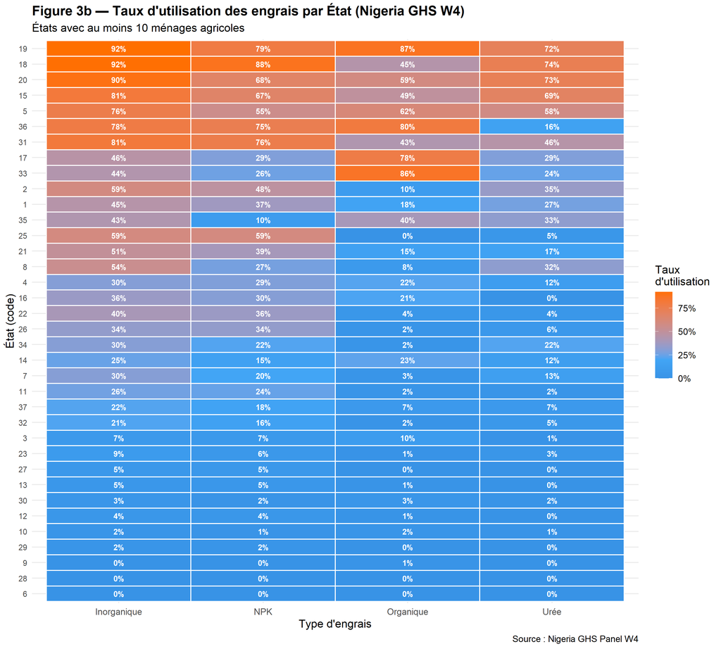

```r
fert_state <- fert_hh %>%
  group_by(state) %>%
  summarise(
    Inorganique = mean(inorganic, na.rm = TRUE),
    Organique   = mean(organic,   na.rm = TRUE),
    NPK         = mean(npk,       na.rm = TRUE),
    Urée        = mean(urea,      na.rm = TRUE),
    n           = n(),
    .groups     = "drop"
  ) %>%
  filter(n >= 10) %>%   # exclure états avec trop peu d'observations
  pivot_longer(
    cols      = c(Inorganique, Organique, NPK, Urée),
    names_to  = "type_engrais",
    values_to = "rate"
  )

ggplot(fert_state, aes(x = type_engrais, y = reorder(factor(state), rate), fill = rate)) +
  geom_tile(color = "white", linewidth = 0.5) +
  geom_text(aes(label = percent(rate, accuracy = 1)), size = 2.8, color = "white",
            fontface = "bold") +
  scale_fill_gradient2(
    low      = "#1565C0",
    mid      = "#42A5F5",
    high     = "#FF6F00",
    midpoint = 0.2,
    labels   = percent_format(accuracy = 1),
    name     = "Taux\nd'utilisation"
  ) +
  labs(
    title    = "Figure 3b — Taux d'utilisation des engrais par État (Nigeria GHS W4)",
    subtitle = "États avec au moins 10 ménages agricoles",
    x        = "Type d'engrais",
    y        = "État (code)",
    caption  = "Source : Nigeria GHS Panel W4"
  ) +
  theme_minimal(base_size = 11) +
  theme(
    plot.title  = element_text(face = "bold"),
    axis.text.y = element_text(size = 8),
    legend.position = "right"
  )
```

**Commentaire.** Le test du chi-deux évalue l’indépendance entre le milieu de résidence et l’usage des engrais inorganiques. La disparité est significative si p < 0,05. Le V de Cramér mesure l’intensité de l’association (0 = indépendance, 1 = association parfaite). La heatmap révèle les disparités inter-étatiques dans l’adoption des intrants, qui reflètent à la fois les politiques d’encadrement agricole et les conditions agro-écologiques.